# 3.Forecasting

### Time series data

https://www.google.com/finance

### What is different?

- Data are dependent over time
- Specific pattern types
- Trends - long term increase or decrease
- Seasonal patterns - patterns related to time of week, month, year, etc.
- Cycles - patterns that rise and fall periodically
- Subsampling into training/test is more complicated
- Similar issues arise in spatial data
- Dependency between nearby observations
- Location specific effects
- Typically goal is to predict one or more observations into the future.
- All standard predictions can be used (with caution!)

### Beware spurious correlations!

http://www.google.com/trends/correlate

http://www.newscientist.com/blogs/onepercent/2011/05/google-correlate-passes-our-we.html

### Also common in geographic analyses

http://xkcd.com/1138/

### Beware extrapolation!

http://www.nature.com/nature/journal/v431/n7008/full/431525a.html

### Google data

```r
library(quantmod)
from.dat <- as.Date("01/01/08", format="%m/%d/%y")
to.dat <- as.Date("12/31/13", format="%m/%d/%y")
getSymbols("GOOG", src="yahoo", from = from.dat, to = to.dat)
```

```
[1] "GOOG"
```

```r
head(GOOG)
```

```
           GOOG.Open GOOG.High GOOG.Low GOOG.Close GOOG.Volume GOOG.Adjusted
2008-01-02  344.1963  346.4318 336.6753   340.3811     8669700      340.3811
2008-01-03  340.4159  341.2058 336.0742   340.4507     6547200      340.4507
2008-01-04  337.6489  338.2798 325.3837   326.3772    10789200      326.3772
2008-01-07  324.8571  329.0002 316.6157   322.5273    12890000      322.5273
2008-01-08  324.3902  327.8477 313.4612   313.7990    10747500      313.7990
2008-01-09  312.9843  324.5591 309.2437   324.4895    13566900      324.4895
```

### Summarize monthly and store as time series

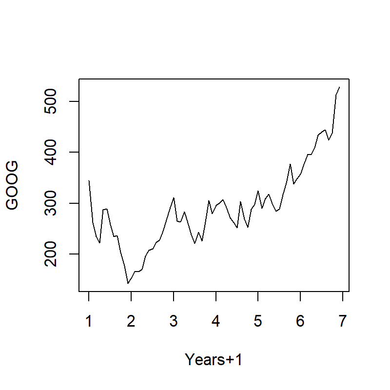

```r
mGoog <- to.monthly(GOOG)
googOpen <- Op(mGoog)
ts1 <- ts(googOpen,frequency=12)
plot(ts1,xlab="Years+1", ylab="GOOG")
```

### Example time series decomposition

- **Trend** - Consistently increasing pattern over time
- **Seasonal** - When there is a pattern over a fixed period of time that recurs.
- **Cyclic** - When data rises and falls over non fixed periods

https://www.otexts.org/fpp/6/1

### Decompose a time series into parts

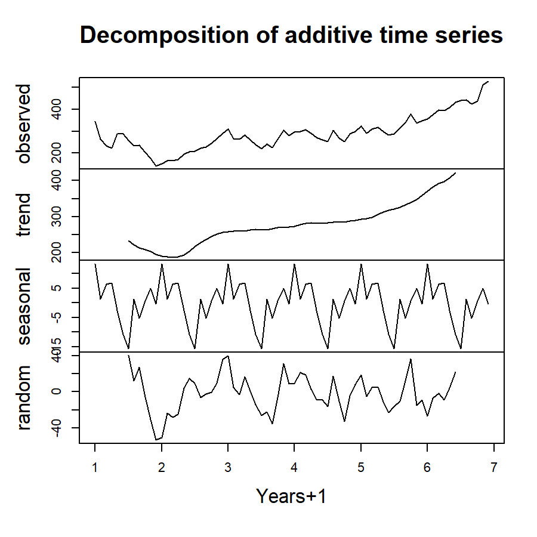

```r
plot(decompose(ts1),xlab="Years+1")
```

### Training and test sets

```r
ts1Train <- window(ts1,start=1,end=5)
ts1Test <- window(ts1,start=5,end=(7-0.01))
ts1Train
```

```
       Jan      Feb      Mar      Apr      May      Jun      Jul      Aug      Sep      Oct
1 344.1963 262.6269 234.2316 222.4234 287.2865 289.3680 258.1112 234.7283 236.8446 204.2466
2 153.3029 166.0649 165.5880 170.7793 196.2387 208.0121 210.7294 222.9201 228.3548 244.9071
3 311.4493 265.5727 262.8902 283.8290 261.5489 238.6627 221.2063 242.9151 226.0200 263.2876
4 296.3128 300.2919 306.8940 292.4777 271.0869 262.3139 251.7327 303.6351 268.6278 253.2777
5 324.3604
       Nov      Dec
1 177.6347 142.4137
2 266.8047 292.1648
3 305.8756 279.6809
4 288.1757 298.0614
5
```

### Simple moving average

$$Y_{t}=\frac{1}{2*k+1}\sum_{j=-k}^k {y_{t+j}}$$

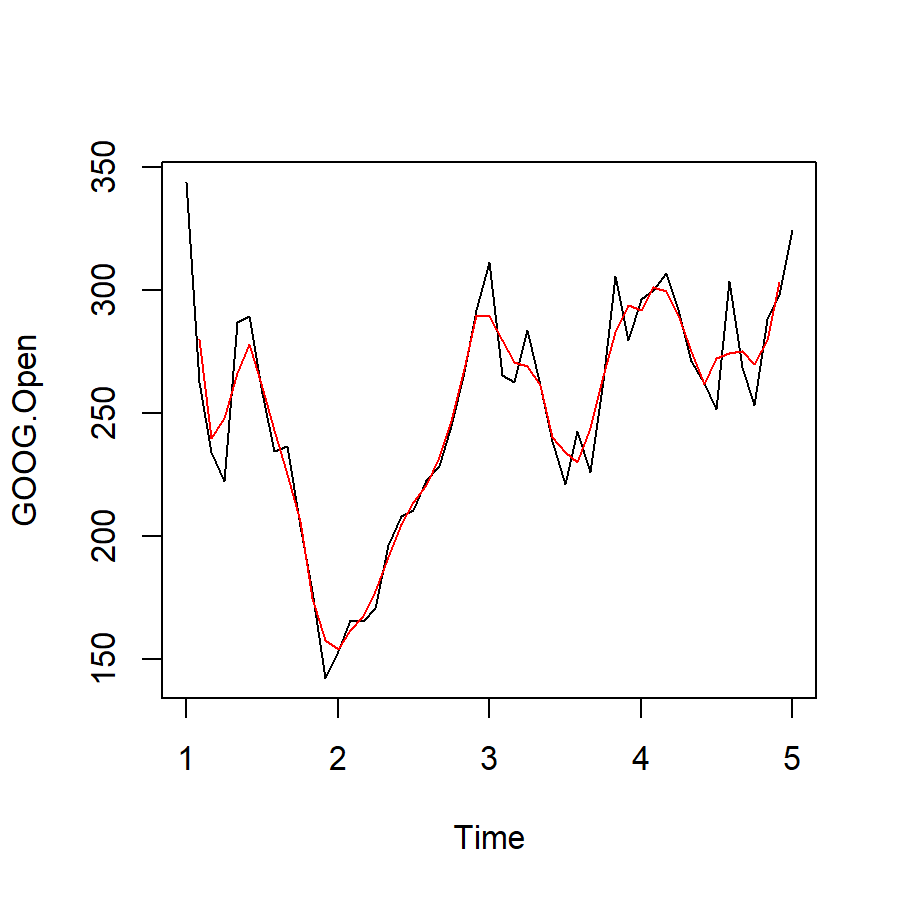

```r
require(forecast)
{plot(ts1Train)
lines(ma(ts1Train,order=3),col="red")}
```

### Exponential smoothing

**Example - simple exponential smoothing**
$$\hat{y}_{t+1} = \alpha y_t + (1-\alpha)\hat{y}_{t-1}$$

More weight on nerby value to the current time and less wegith on far value from the current period.

https://www.otexts.org/fpp/7/6

### Exponential smoothing

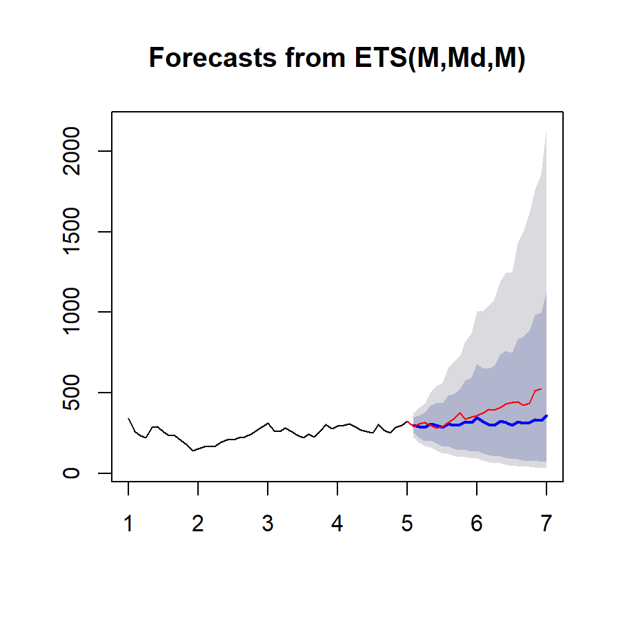

```r
ets1 <- ets(ts1Train,model="MMM")
fcast <- forecast(ets1)
plot(fcast); lines(ts1Test,col="red")
```

### Get the accuracy

```r
accuracy(fcast,ts1Test)
```

```
                     ME     RMSE      MAE        MPE      MAPE      MASE        ACF1 Theil's U
Training set -0.4233705 25.92357 20.65793 -0.5722018  8.330302 0.3944374 0.001894222        NA
Test set     66.3415609 89.94422 69.37055 15.3933400 16.440355 1.3245443 0.752587668  3.266365
```

### Notes and further resources

- [Forecasting and timeseries prediction](http://en.wikipedia.org/wiki/Forecasting) is an entire field
- Rob Hyndman’s [Forecasting: principles and practice](https://www.otexts.org/fpp/) is a good place to start
- Cautions
- Be wary of spurious correlations
- Be careful how far you predict (extrapolation)
- Be wary of dependencies over time
- See [quantmod](http://cran.r-project.org/web/packages/quantmod/quantmod.pdf) or [quandl](http://www.quandl.com/help/packages/r) packages for finance-related problems.